# Reproducible researche / Course project 1 / Week 2

xetaro

28 juillet 2016

```r
Sys.setlocale("LC_TIME", "English")
```

```
## [1] "English_United States.1252"
```

1.Code for reading in the dataset and/or processing the data

Unzip and load the data

```r
unzip("Activity.zip")
activity <- read.csv("activity.csv")
```

Classes of data set columns

```r
str(activity)
```

```
## 'data.frame':    17568 obs. of  3 variables:
##  $ steps   : int  NA NA NA NA NA NA NA NA NA NA ...
##  $ date    : Factor w/ 61 levels "2012-10-01","2012-10-02",..: 1 1 1 1 1 1 1 1 1 1 ...
##  $ interval: int  0 5 10 15 20 25 30 35 40 45 ...
```

```r
dim(activity)
```

```
## [1] 17568     3
```

```r
names(activity)
```

```
## [1] "steps"    "date"     "interval"
```

date needs to be converted:

convert date info in format ‘yyyy-mm-dd’

```r
activity$date <- as.Date(activity$date, "%Y-%m-%d")
activity$date
```

Summary of data set:

```r
summary(activity)
```

```
##      steps             date               interval
##  Min.   :  0.00   Min.   :2012-10-01   Min.   :   0.0
##  1st Qu.:  0.00   1st Qu.:2012-10-16   1st Qu.: 588.8
##  Median :  0.00   Median :2012-10-31   Median :1177.5
##  Mean   : 37.38   Mean   :2012-10-31   Mean   :1177.5
##  3rd Qu.: 12.00   3rd Qu.:2012-11-15   3rd Qu.:1766.2
##  Max.   :806.00   Max.   :2012-11-30   Max.   :2355.0
##  NA's   :2304
```

Calculate the total number of steps taken per day:

```r
stepsPerDay <- aggregate(steps ~ date, activity, sum, na.rm=TRUE)
sum(stepsPerDay$steps)
```

```
## [1] 570608
```

```r
sum(activity[!is.na(activity$steps),]$steps)
```

```
## [1] 570608
```

2.Histogram of the total number of steps taken each day

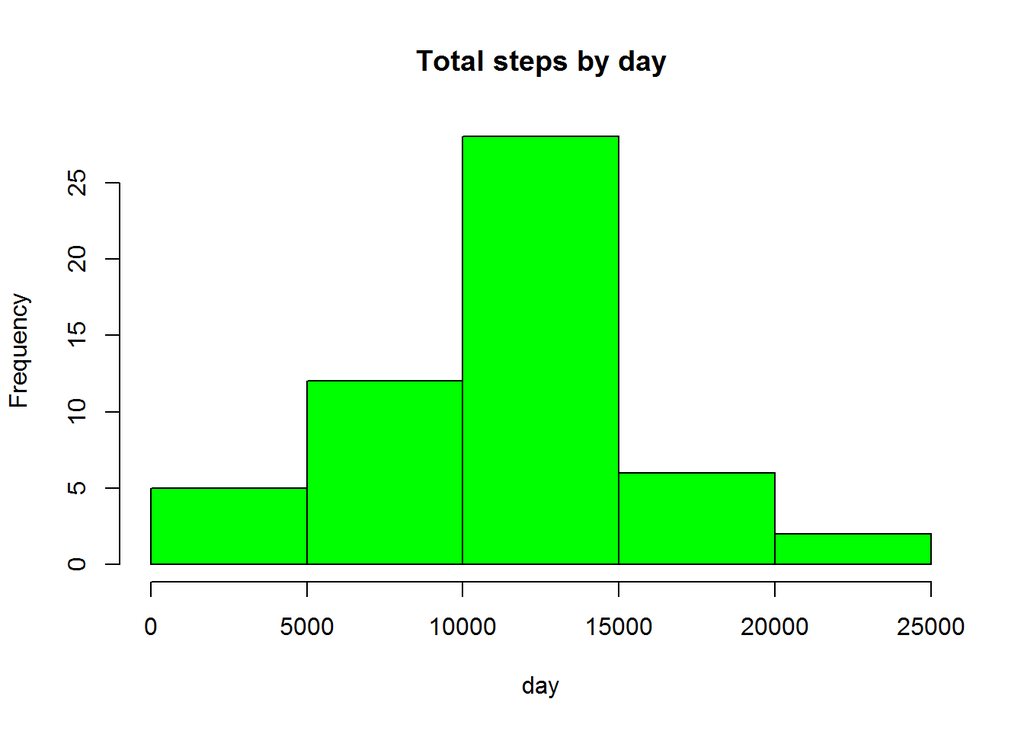

```r
hist(stepsPerDay$steps, main = "Total steps by day", xlab = "day", col = "green")
```

https://github.com/xetaro/RepData_PeerAssessment1/blob/master/plot_1.png

3.Mean and median number of steps taken each day

```r
mean(stepsPerDay$steps)
```

```
## [1] 10766.19
```

```r
median(stepsPerDay$steps)
```

```
## [1] 10765
```

4.Time series plot of the average number of steps taken

Make a time series plot of the 5-minute interval (x-axis) and the average number of steps taken, averaged across all days (y-axis)

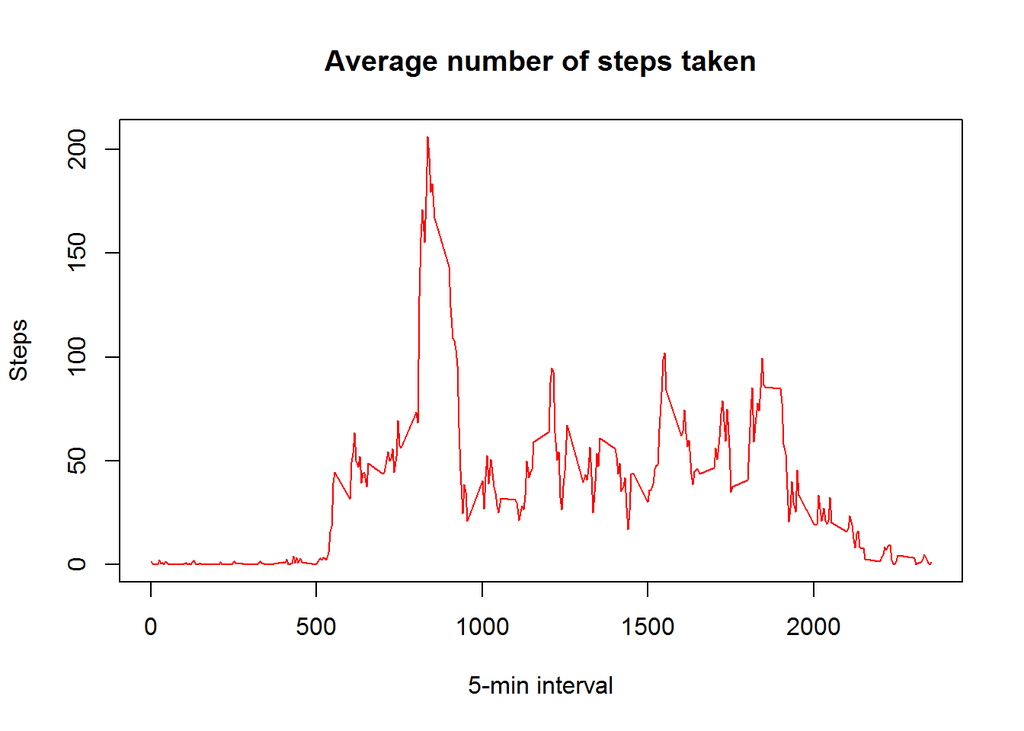

```r
avgStepsPerInterval <- aggregate(steps ~ interval, activity, mean)

plot(avgStepsPerInterval, type = "l", xlab = "5-min interval",
    ylab = "Steps", main = "Average number of steps taken",col= "red")
```

https://github.com/xetaro/RepData_PeerAssessment1/blob/master/plot_2.png

5.The 5-minute interval that, on average, contains the maximum number of steps

```r
avgStepsPerInterval[avgStepsPerInterval$steps==max(avgStepsPerInterval$steps),]
```

```
##     interval    steps
## 104      835 206.1698
```

Interval 835 with approx. 206 steps contians the maximum number of steps.

6. Code to describe and show a strategy for imputing missing data

Calculate and report the total number of missing values in the dataset (i.e. the total number of rows with NAs):

```r
table(is.na(activity$steps))
```

```
##
## FALSE  TRUE
## 15264  2304
```

```r
table(is.na(activity$date))
```

```
##
## FALSE
## 17568
```

```r
table(is.na(activity$interval))
```

```
##
## FALSE
## 17568
```

2304 values are NA (all for steps).

Strategy for filling the NA’s: mean for that 5-minute interval

```r
activityFilled <- merge(x = activity, y = avgStepsPerInterval, by="interval", all.x=T)

activityFilled[is.na(activityFilled$steps.x),]$steps.x <-activityFilled[is.na(activityFilled$steps.x),]$steps.y

head(activityFilled)
```

```
##   interval  steps.x       date  steps.y
## 1        0 1.716981 2012-10-01 1.716981
## 2        0 0.000000 2012-11-23 1.716981
## 3        0 0.000000 2012-10-28 1.716981
## 4        0 0.000000 2012-11-06 1.716981
## 5        0 0.000000 2012-11-24 1.716981
## 6        0 0.000000 2012-11-15 1.716981
```

```r
activityFilled <- activityFilled[,c(1:3)]

names(activityFilled) <- c("interval", "steps", "date")

head(activityFilled)
```

```
##   interval    steps       date
## 1        0 1.716981 2012-10-01
## 2        0 0.000000 2012-11-23
## 3        0 0.000000 2012-10-28
## 4        0 0.000000 2012-11-06
## 5        0 0.000000 2012-11-24
## 6        0 0.000000 2012-11-15
```

7. Histogram of the total number of steps taken each day after missing values are imputed

```r
stepsPerDayFilled <- aggregate(steps ~ date, activityFilled, sum)
```

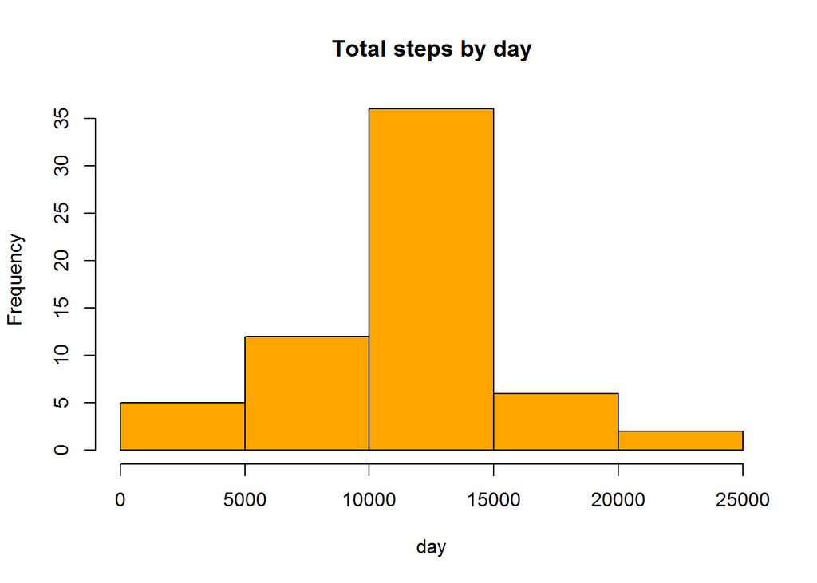

```r
hist(stepsPerDayFilled$steps, main = "Total steps by day", xlab = "day", col = "orange")
```

https://github.com/xetaro/RepData_PeerAssessment1/blob/master/plot_3.png

```r
mean(stepsPerDayFilled$steps)
```

```
## [1] 10766.19
```

```r
median(stepsPerDayFilled$steps)
```

```
## [1] 10766.19
```

Data for comparison from earlier:

```r
mean(stepsPerDay$steps)
```

```
## [1] 10766.19
```

```r
median(stepsPerDay$steps)
```

```
## [1] 10765
```

Mean does not change, but the median does a little bit (1 step), but the histogram shows, that the data is more centered.

8. Panel plot comparing the average number of steps taken per 5-minute interval across weekdays and weekends

Create a new factor variable in the dataset with two levels - “weekday” and “weekend” indicating whether a given date is a weekday or weekend day.

```r
activityFilled$wd <- factor(format(activity$date, "%A"))

levels(activityFilled$wd)
```

```
## [1] "Friday"    "Monday"    "Saturday"  "Sunday"    "Thursday"  "Tuesday"
## [7] "Wednesday"
```

```r
levels(activityFilled$wd) <- list(Weekday = c("Friday","Monday","Thursday","Tuesday","Wednesday"), Weekend = c("Saturday","Sunday"))
levels(activityFilled$wd)
```

```
## [1] "Weekday" "Weekend"
```

```r
table(activityFilled$wd)
```

```
##
## Weekday Weekend
##   12960    4608
```

Make a panel plot containing a time series plot (i.e. type = “l”) of the 5-minute interval (x-axis) and the average number of steps taken, averaged across all weekday days or weekend days (y-axis)

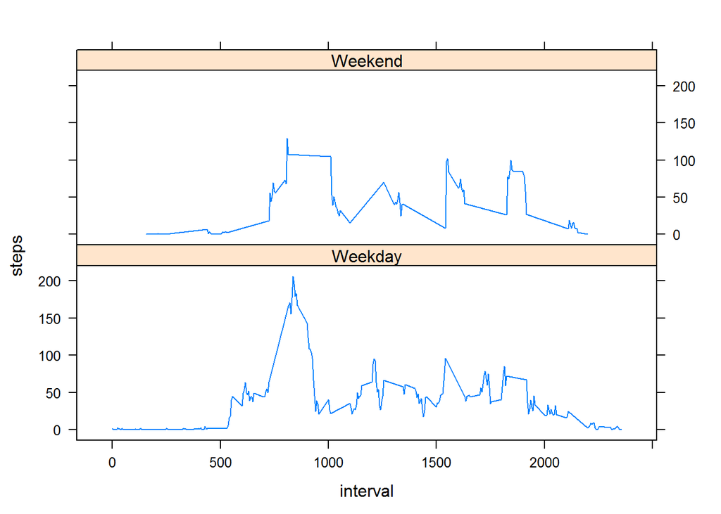

```r
avgStepsPerIntervalWithWeekday <- aggregate(steps ~ interval + wd, activityFilled, mean)

library(lattice)

xyplot(steps ~ interval | factor(wd), data=avgStepsPerIntervalWithWeekday, type = "l", layout=c(1,2))
```

https://github.com/xetaro/RepData_PeerAssessment1/blob/master/plot_4.png

We can see at the graph above that activity on the weekday has the greatest peak from all steps intervals. But, we can see too that weekends activities has more peaks over a hundred than weekday. This could be due to the fact that activities on weekdays mostly follow a work related routine, where we find some more intensity activity in little a free time that the employ can made some sport. In the other hand, at weekend we can see better distribution of effort along the time.